# 2018week12 on igraph

Vicki Hertzberg

4/18/2018

Load up package:

```r
library(igraph); packageVersion("igraph")
```

```
## [1] '1.2.1'
```

#### Making the networks

For small graphs, one easy way to get data into igraph is to open up an editing window, as follows:

```r
datafab <- edit(data.frame()) #enter edges
```

You can then turn this data frame into a graph as follows:

```r
g <- graph.data.frame(datafab, directed = FALSE) # turn edge list into graph
g # list the graph
```

```
## IGRAPH efa5a52 UN-- 7 10 --
## + attr: name (v/c)
## + edges from efa5a52 (vertex names):
##  [1] Alice--Bob   Alice--Sue   Bob  --Jim   Bob  --Sue   Sue  --Ellen
##  [6] Jim  --Frank Jim  --Ellen Jim  --Karen Ellen--Frank Frank--Karen
```

```r
summary(g) # find out about the graph
```

```
## IGRAPH efa5a52 UN-- 7 10 --
## + attr: name (v/c)
```

```r
V(g) # list the vertices of the graph
```

```
## + 7/7 vertices, named, from efa5a52:
## [1] Alice Bob   Sue   Jim   Ellen Frank Karen
```

```r
E(g) # list the edges of the graph
```

```
## + 10/10 edges from efa5a52 (vertex names):
##  [1] Alice--Bob   Alice--Sue   Bob  --Jim   Bob  --Sue   Sue  --Ellen
##  [6] Jim  --Frank Jim  --Ellen Jim  --Karen Ellen--Frank Frank--Karen
```

You can also create a graph from a set of excel files documenting the vertex (or node) names and the edges. First start with an empty graph

```r
g <- graph.empty() #start with empty graph
traits <- read.csv("traits.csv", head = FALSE) # read in the vertices
relations <- read.csv("relations.csv", head = FALSE) # read in the edges

# add vertices to the empty graph
g <- add.vertices(g, nv = nrow(traits), name = as.character(traits[,1]), age = traits[,2], gender = as.character(traits[,3]))

# check that graph is being created properly

V(g)$name
```

```
##  [1] "Alice Anderson"    "Bob Bradford"      "Cecil Connor"
##  [4] "David Daugher"     "Esmeralda Escobar" "Frank Finley"
##  [7] "Gabi Garbo"        "Helen Hunt"        "Iris Irving"
## [10] "James Jones"
```

```r
V(g)$age
```

```
##  [1] 48 33 45 34 21 36 44 40 25 47
```

```r
V(g)$gender
```

```
##  [1] "F" "M" "F" "M" "F" "M" "F" "F" "F" "M"
```

```r
# strip out the last names

names <- sapply(strsplit(V(g)$name, " "), "[", 1)
ids <- 1:length(names)
names(ids) <- names

# list the ids

ids
```

```
##     Alice       Bob     Cecil     David Esmeralda     Frank      Gabi
##         1         2         3         4         5         6         7
##     Helen      Iris     James
##         8         9        10
```

```r
# create an edges list with vertex ids instead of names

from <- as.character(relations[,1])
to <- as.character(relations[,2])
edges <- matrix(c(ids[from], ids[to]), nc = 2)

# list the edges

edges
```

```
##       [,1] [,2]
##  [1,]    2    1
##  [2,]    3    2
##  [3,]    3    1
##  [4,]    4    1
##  [5,]    4    2
##  [6,]    5    1
##  [7,]    6    1
##  [8,]    6    5
##  [9,]    7    2
## [10,]    7    1
## [11,]    8    1
## [12,]    9    3
## [13,]    9    2
## [14,]    9    5
```

[output cut: 20 more lines]

```r
# add edges to the graph, along with edge attributes

g <- add.edges(g, t(edges), room = as.character(relations[,3]), friend = relations[,4], advice = relations[,5])
```

There are other ways to import pre-existing graphs, provided you know the formats.

As seen above from the Alice and Bob example, we can import an edgelist. Another popular format is that used in the package Pajek. Still another common format is `GML`.

```r
# Import an edge list
dolphins <- read.graph("dolphins.txt", format = c("edgelist"))
dolphins
```

```
## IGRAPH ab56f16 D--- 63 159 --
## + edges from ab56f16:
##  [1]  5->10  7->11  8->11  2->12  4->12  7->15  8->15 11->15  2->16  5->16
## [11]  2->17 16->18  3->19  8->19 11->19 15->19 17->20  3->21  9->21 10->22
## [21] 18->22 20->22 20->23 19->24 16->26 17->26 20->26 19->27  3->28 27->28
## [31]  3->29  9->29 19->29 27->29 28->29  3->30 10->30 22->30 12->31 20->31
## [41] 23->31 26->31  9->32 21->32 30->32 19->33 11->34 15->34 14->35 16->35
## [51] 18->35 23->35 16->36 35->36 31->37  3->38 22->38 25->38 10->39 16->39
## [61] 18->39 23->39 35->39 36->39 38->39 16->40 18->40 22->40 35->40 38->41
## [71]  2->42  9->42 16->42 17->42 35->42 38->42 39->42  3->43 11->43 15->43
## [81]  2->44  4->44 12->44 32->44 16->45 31->45 35->45 39->45 40->45  4->46
## + ... omitted several edges
```

```r
# Leave edges as undirected
dolphins <- read.graph("dolphins.txt", directed=FALSE, format = "edgelist")
dolphins
```

```
## IGRAPH 3a90f6a U--- 63 159 --
## + edges from 3a90f6a:
##  [1]  5--10  7--11  8--11  2--12  4--12  7--15  8--15 11--15  2--16  5--16
## [11]  2--17 16--18  3--19  8--19 11--19 15--19 17--20  3--21  9--21 10--22
## [21] 18--22 20--22 20--23 19--24 16--26 17--26 20--26 19--27  3--28 27--28
## [31]  3--29  9--29 19--29 27--29 28--29  3--30 10--30 22--30 12--31 20--31
## [41] 23--31 26--31  9--32 21--32 30--32 19--33 11--34 15--34 14--35 16--35
## [51] 18--35 23--35 16--36 35--36 31--37  3--38 22--38 25--38 10--39 16--39
## [61] 18--39 23--39 35--39 36--39 38--39 16--40 18--40 22--40 35--40 38--41
## [71]  2--42  9--42 16--42 17--42 35--42 38--42 39--42  3--43 11--43 15--43
## [81]  2--44  4--44 12--44 32--44 16--45 31--45 35--45 39--45 40--45  4--46
## + ... omitted several edges
```

```r
# Import a graph make in Pajek
karate <- read.graph("karate.txt", format = "pajek")
karate
```

```
## IGRAPH 123ac9e UN-- 34 78 --
## + attr: id (v/c), name (v/c)
## + edges from 123ac9e (vertex names):
##  [1] 1 --2  1 --3  2 --3  1 --4  2 --4  3 --4  1 --5  1 --6  1 --7  5 --7
## [11] 6 --7  1 --8  2 --8  3 --8  4 --8  1 --9  3 --9  3 --10 1 --11 5 --11
## [21] 6 --11 1 --12 1 --13 4 --13 1 --14 2 --14 3 --14 4 --14 6 --17 7 --17
## [31] 1 --18 2 --18 1 --20 2 --20 1 --22 2 --22 24--26 25--26 3 --28 24--28
## [41] 25--28 3 --29 24--30 27--30 2 --31 9 --31 1 --32 25--32 26--32 29--32
## [51] 3 --33 9 --33 15--33 16--33 19--33 21--33 23--33 24--33 30--33 31--33
## [61] 32--33 9 --34 10--34 14--34 15--34 16--34 19--34 20--34 21--34 23--34
## [71] 24--34 27--34 28--34 29--34 30--34 31--34 32--34 33--34
```

```r
# Import a graph in GML format

football <- read.graph("football.gml", format="gml")
football
```

```
## IGRAPH 02e8d89 U--- 115 616 --
## + attr: id (v/n), label (v/c), value (v/n)
## + edges from 02e8d89:
##  [1]  1-- 2  3-- 4  1-- 5  5-- 6  4-- 6  3-- 7  7-- 8  8-- 9  9--10  1--10
## [11]  5--10  6--11 11--12  6--12  4--12 13--14  3--14  3--15 13--15 15--16
## [21] 14--16  3--16  5--17 10--17  1--17 17--18 13--18 13--19 19--20 18--21
## [31] 21--22  9--22  8--22 10--23  8--23 22--23  9--23 23--24 10--24  5--24
## [41] 17--24  1--24 12--25 25--26  2--26  4--27 13--27 15--27 27--28 18--28
## [51]  2--28 18--28  5--29 12--29 25--29 20--30 30--31 20--31 19--32 32--33
## [61] 22--33 16--33 14--33  7--33  1--34  2--34 26--34 20--34 32--35 27--35
## [71] 13--35 19--35 35--36  1--36 30--36 20--36 31--36 19--37 13--37 21--37
## + ... omitted several edges
```

#### Plotting the networks

There are two ways to plot within `igraph`. The function `plot.igraph` gives you a static plot, while the function `tkplot` gives you more interactive capability. Note you must have XQuartz functioning (Mac users) for `tkplot` to work.

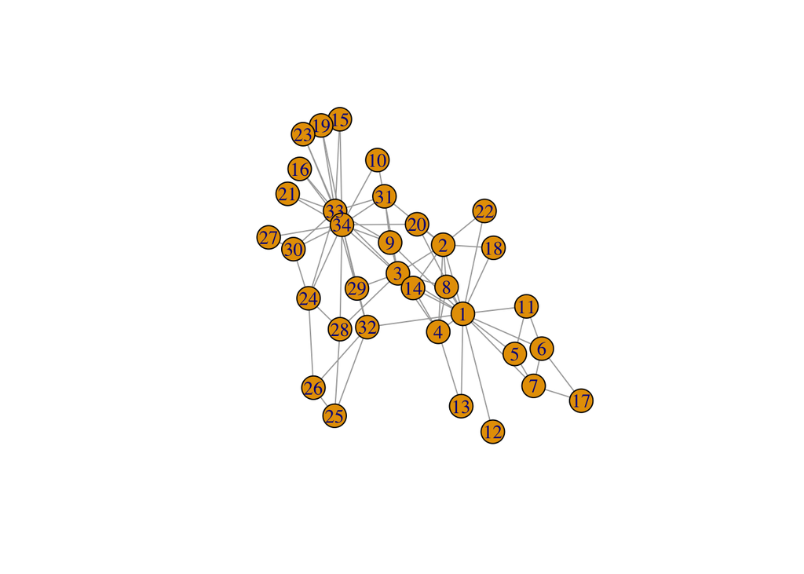

```r
# Plotting

plot.igraph(karate)
```

```r
# Another way

tkplot(karate)
```

```
## [1] 1
```

You can also do some more with color, as follows:

```r
E(g)$color <- "black"
E(g)[room =="Y"]$color <- "red"

tkplot(g, layout = layout.kamada.kawai, edge.color = E(g)$color)
```

```
## [1] 2
```

#### Graph and Vertex Properties

You can determine properties of the graph as a whole as well as those of individual vertices very easily in `igraph`.

```r
# Determine the degree sequence

degree(karate)
```

```
##  1  2  3  4  5  6  7  8  9 10 11 12 13 14 15 16 17 18 19 20 21 22 23 24 25
## 16  9 10  6  3  4  4  4  5  2  3  1  2  5  2  2  2  2  2  3  2  2  2  5  3
## 26 27 28 29 30 31 32 33 34
##  3  2  4  3  4  4  6 12 17
```

```r
# Determine the diameter of the graph

diameter(karate)
```

```
## [1] 5
```

```r
# Calculate the closeness centrality for each vertex

closeness(karate)
```

```
##          1          2          3          4          5          6
## 0.01724138 0.01470588 0.01694915 0.01408451 0.01149425 0.01162791
##          7          8          9         10         11         12
## 0.01162791 0.01333333 0.01562500 0.01315789 0.01149425 0.01111111
##         13         14         15         16         17         18
## 0.01123596 0.01562500 0.01123596 0.01123596 0.00862069 0.01136364
##         19         20         21         22         23         24
## 0.01123596 0.01515152 0.01123596 0.01136364 0.01123596 0.01190476
##         25         26         27         28         29         30
## 0.01136364 0.01136364 0.01098901 0.01388889 0.01369863 0.01162791
##         31         32         33         34
## 0.01388889 0.01639344 0.01562500 0.01666667
```

```r
# Note for directed graphs, you can use the  mode option to determine the in-, out-, or all-closeness properties, as follows:

closeness(karate, mode="in")
```

```
##          1          2          3          4          5          6
## 0.01724138 0.01470588 0.01694915 0.01408451 0.01149425 0.01162791
##          7          8          9         10         11         12
## 0.01162791 0.01333333 0.01562500 0.01315789 0.01149425 0.01111111
##         13         14         15         16         17         18
## 0.01123596 0.01562500 0.01123596 0.01123596 0.00862069 0.01136364
##         19         20         21         22         23         24
## 0.01123596 0.01515152 0.01123596 0.01136364 0.01123596 0.01190476
##         25         26         27         28         29         30
## 0.01136364 0.01136364 0.01098901 0.01388889 0.01369863 0.01162791
##         31         32         33         34
## 0.01388889 0.01639344 0.01562500 0.01666667
```

```r
closeness(karate, mode = "out")
```

```
##          1          2          3          4          5          6
## 0.01724138 0.01470588 0.01694915 0.01408451 0.01149425 0.01162791
##          7          8          9         10         11         12
## 0.01162791 0.01333333 0.01562500 0.01315789 0.01149425 0.01111111
##         13         14         15         16         17         18
## 0.01123596 0.01562500 0.01123596 0.01123596 0.00862069 0.01136364
##         19         20         21         22         23         24
## 0.01123596 0.01515152 0.01123596 0.01136364 0.01123596 0.01190476
##         25         26         27         28         29         30
## 0.01136364 0.01136364 0.01098901 0.01388889 0.01369863 0.01162791
##         31         32         33         34
## 0.01388889 0.01639344 0.01562500 0.01666667
```

```r
closeness(karate, mode = "all")
```

```
##          1          2          3          4          5          6
## 0.01724138 0.01470588 0.01694915 0.01408451 0.01149425 0.01162791
##          7          8          9         10         11         12
## 0.01162791 0.01333333 0.01562500 0.01315789 0.01149425 0.01111111
##         13         14         15         16         17         18
## 0.01123596 0.01562500 0.01123596 0.01123596 0.00862069 0.01136364
##         19         20         21         22         23         24
## 0.01123596 0.01515152 0.01123596 0.01136364 0.01123596 0.01190476
##         25         26         27         28         29         30
## 0.01136364 0.01136364 0.01098901 0.01388889 0.01369863 0.01162791
##         31         32         33         34
## 0.01388889 0.01639344 0.01562500 0.01666667
```

```r
# Calculate the betweenness centrality for each vertex

betweenness(karate)
```

```
##           1           2           3           4           5           6
## 231.0714286  28.4785714  75.8507937   6.2880952   0.3333333  15.8333333
##           7           8           9          10          11          12
##  15.8333333   0.0000000  29.5293651   0.4476190   0.3333333   0.0000000
##          13          14          15          16          17          18
##   0.0000000  24.2158730   0.0000000   0.0000000   0.0000000   0.0000000
##          19          20          21          22          23          24
##   0.0000000  17.1468254   0.0000000   0.0000000   0.0000000   9.3000000
##          25          26          27          28          29          30
##   1.1666667   2.0277778   0.0000000  11.7920635   0.9476190   1.5428571
##          31          32          33          34
##   7.6095238  73.0095238  76.6904762 160.5515873
```

```r
# And for directed graphs

betweenness(karate, directed = "TRUE")
```

```
##           1           2           3           4           5           6
## 231.0714286  28.4785714  75.8507937   6.2880952   0.3333333  15.8333333
##           7           8           9          10          11          12
##  15.8333333   0.0000000  29.5293651   0.4476190   0.3333333   0.0000000
##          13          14          15          16          17          18
##   0.0000000  24.2158730   0.0000000   0.0000000   0.0000000   0.0000000
##          19          20          21          22          23          24
##   0.0000000  17.1468254   0.0000000   0.0000000   0.0000000   9.3000000
##          25          26          27          28          29          30
##   1.1666667   2.0277778   0.0000000  11.7920635   0.9476190   1.5428571
##          31          32          33          34
##   7.6095238  73.0095238  76.6904762 160.5515873
```

#### Want to try more?

In the repo there are two more datasets. The dataset `lesmis.txt` is a Pajek file denoting the characters in the play “Les Mis”, and two characters are related when they appear on stage at the same time. The dataset `adjnoun.gml` is a GML formatted graph that describes the word concurrencies in “David Copperfield”.